QRM: Third Meeting

# Research Methodology in Social Sciences

Dr. David Sichinava  
October 19, 2018

Third Meeting

### Today's meeting

- Probability distributions
- Lab

### Introduction to probability

- How do we unedrstand probability?
  - Frequentist approach
  - Bayesian approach
- Why do we need probabilities?

### Introduction to probability

- Through this class, we will use *frequentist* understanding of probability, that is:
  - “the proportion of times the outcome would occur in a very long sequence of observations”
  - Usually, probabilities are expressed in numbers between 0 and 1, or - in percentages.

### Introduction to probability

Probability has many properties, although the following are the most important (for us):

- \( P(not A)= 1- P(A) \)
- \( P(A or B) = P(A) + P(B) \)
- \( P(A and B) = P(A)*P(B) \)

### Introduction to probability

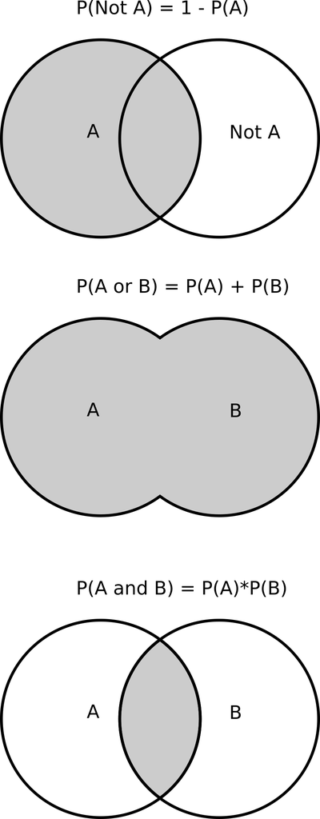

### Random variables

- Let's imagine that we are doing an experiment or drawing a sample from population;
- Each possible outcome of the variable has a certain probability of occuring
- We call these variables *random variables*
- Set of these possible outcomes is called *probability distribution*. Based on probability theory (and math) we can estimate these values.

### Discrete and continuous (random) variables

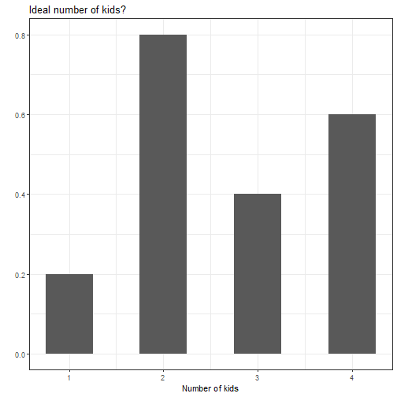

### Discrete and continuous (random) variables

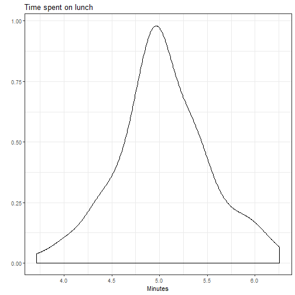

### Parameters describing probability distributions

- Probability distributions have formulas for calulating probabilities:
  - Mean, measuring the *expected value* of a distribution,
  - Standard deviation, measuring the *spread* of a distribution

### Normal distribution

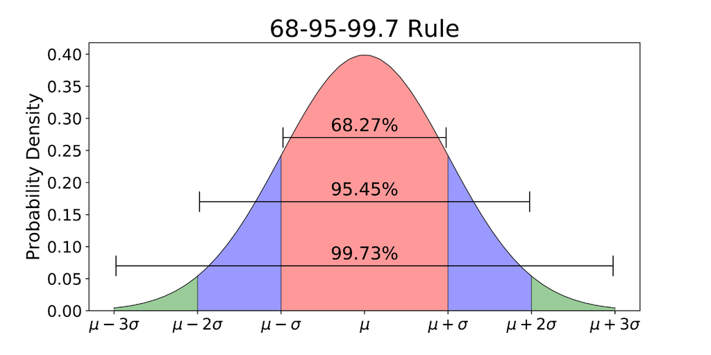

### Normal distribution

- In normal distribution, the probability of \( \mu \) within any particular number of \( \sigma \) standard deviations is the same (0.68 for one \( \sigma \), 0.95 for two \( \sigma \) and 0.997 for three \( \sigma \))
- For normal distribution, for each value of \( z \), the probability of falling within \( z \) standard deviation from the mean depends on the value of \( z \). For instance, the value of two standard deviations above the mean has z-value of 2.00
- Put it simply, \( z \)-score is the number of standard deviations from the mean
- It is an useful way of calculating a probability of a particular value in the distribution (and comparing it to other groups)
- \( z=(y-\mu)/\sigma \)

### Sampling distribution

- We rarely have complete data and rely on *samples*
- Sampling distribution of a statistic is the probability distribution that specifies probabilities for the possible values that statistic can take
- That is, we take *many samples* from population, and then calculate the value of sample statistics
- The sampling distribution of the sample mean \( \hat\y \) centers around population mean. Standard deviation, or *standard error* relates to the population \( \sigma \) by \( \sigma_{y}=\sigma/\sqrt{n} \).
  - What will happen, if we increase n?

### Ta-daam! Central Limit Theorem

- For large random samples, the sampling distribution of the sample mean is approximately normal. This holds no matter what the shape of the population is.
- It's one of the foundational principles of frequentist statistical inference

[figure not shown]